# Studying Various Effects of Severe Weather Events

Aman Bhagat

3/26/2020

## Synopsis

In this report we aim to describe the effects of storms and other severe weather events which can cause both public health and economic problems for commumnities and municipaltie. Many severe events can results in fatalities, injuries and property damage, and preventing such outcomes to the extent possible is a key concern.

This project involves exploring the U.S. National Oceanic and Atmoshpheric Administration’s (NOAA) storm database. This database tracks characteristics of major storms and weather events in the United States, including when and where they occur, as well as estimates of any fatalities, injuries and property damage.

## Loading and Processing the Raw Data

From [Storm Data](https://d396qusza40orc.cloudfront.net/repdata%2Fdata%2FStormData.csv.bz2) we obtain the the storm data which is an official publication of the National Oceanic and Atmoshpheric Administration. The data recorded in the file is from 1950 to 2011. We first read the data from the raw csv file which is compressed via bz2 algorithm to reduce its size.

```r
weather <- read.csv("repdata_data_StormData.csv.bz2")
```

After reading the data we check first few rows(there are 902297 rows) of the dataset

```r
dim(weather)
```

```
## [1] 902297     37
```

```r
head(weather[,1:8])
```

```
##   STATE__           BGN_DATE BGN_TIME TIME_ZONE COUNTY COUNTYNAME STATE  EVTYPE
## 1       1  4/18/1950 0:00:00     0130       CST     97     MOBILE    AL TORNADO
## 2       1  4/18/1950 0:00:00     0145       CST      3    BALDWIN    AL TORNADO
## 3       1  2/20/1951 0:00:00     1600       CST     57    FAYETTE    AL TORNADO
## 4       1   6/8/1951 0:00:00     0900       CST     89    MADISON    AL TORNADO
## 5       1 11/15/1951 0:00:00     1500       CST     43    CULLMAN    AL TORNADO
## 6       1 11/15/1951 0:00:00     2000       CST     77 LAUDERDALE    AL TORNADO
```

Here we can see that the Begin Dates are not in the correct DATE format to process the data. So we converted the dates into the the correct date format for the better analysis of the data.

```r
weather$BGN_DATE <- as.Date(weather$BGN_DATE, format = "%m/%d/%Y")
str(weather$BGN_DATE)
```

```
##  Date[1:902297], format: "1950-04-18" "1950-04-18" "1951-02-20" "1951-06-08" "1951-11-15" ...
```

## Questions

1. Across the United States, which types of events (as indicated in the EVTYPE variable) are most harmful with respect to population health?
2. Across the United States, which types of events have the greatest economic consequences?

## Results

> Question 1: Across the United States, which types of events (as indicated in the EVTYPE variable) are most harmful with respect to population health?

**Data processing for the required Plot**

```r
harmful.evtype <- weather %>% group_by(EVTYPE) %>% summarize(Injuries.Total = sum(INJURIES))
Fatalities <- weather %>% group_by(EVTYPE) %>% summarize(Fatalities.Total = sum(FATALITIES))
Fatalities <- Fatalities[order(-Fatalities$Fatalities.Total),]
Fatalities <- Fatalities[1:14,]

df3 <- harmful.evtype %>% filter(Injuries.Total > 1000) #Only the events which caused above 1000 Injuries
```

**Result**

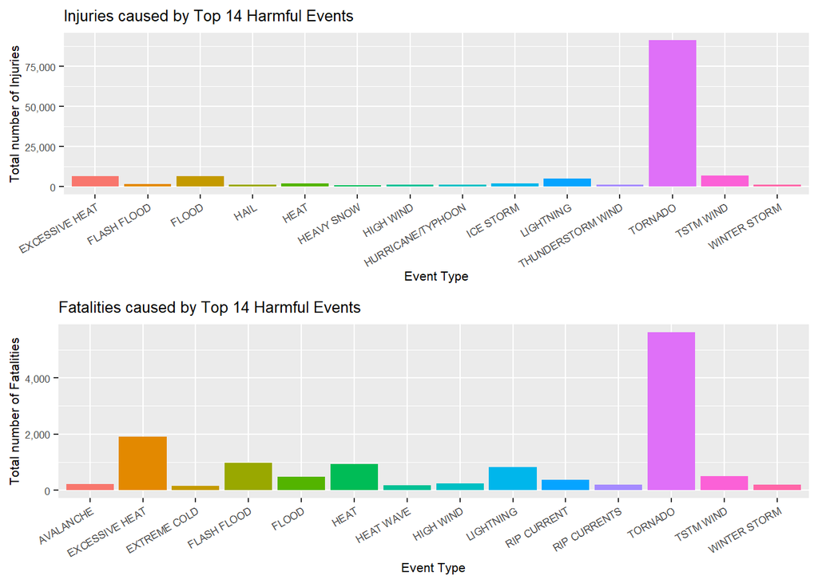

```r
plot1 <- ggplot(data = df3 , aes(y = Injuries.Total , x = EVTYPE, fill = EVTYPE))+
    geom_bar(stat = "identity")+
    guides(fill = FALSE)+
    ggtitle("Injuries caused by Top 14 Harmful Events")+
    xlab("Event Type")+
    ylab("Total number of Injuries")+
    theme(text = element_text(size=8),axis.text.x=element_text(angle = 30,hjust = 1))+
    scale_y_continuous(labels = comma)

plot2 <- ggplot(data = Fatalities , aes(y = Fatalities.Total , x = EVTYPE, fill = EVTYPE))+
    geom_bar(stat = "identity")+
    guides(fill = FALSE)+
    ggtitle("Fatalities caused by Top 14 Harmful Events")+
    xlab("Event Type")+
    ylab("Total number of Fatalities")+
    theme(text = element_text(size=8),axis.text.x=element_text(angle = 30, hjust = 1))+
    scale_y_continuous(labels = comma)

grid.arrange(plot1 , plot2 , nrow = 2)
```

*The above plot show that there are 14 major weather events which cause more Injuries and fatalities and TORNADO has caused more Injuries and fatalities till 2011.*

> Question 2: Across the United States, which types of events have the greatest economic consequences?

As to address the above question we first process the data to get the required data which can be used for plotting and analysis purpose. Here to calaculate total damage caused by the weather events we combine the property damage and crop damage. There are some rows which doesn’t have proper record of the damage, so we only selected the rows which have proper damage reported and then analyzed to get the top events which has caused most damage and have the greatest economic consequences.

**Processing Data**

```r
EconomicEvent <- weather %>% select(EVTYPE,PROPDMG,PROPDMGEXP,CROPDMG,CROPDMGEXP)

#Filtering all the property damage and crop damage
damage <- EconomicEvent %>% filter(PROPDMGEXP == "K" | PROPDMGEXP == "k" | PROPDMGEXP == "m" | PROPDMGEXP == "M" | PROPDMGEXP == "b" | PROPDMGEXP == "B" )

damage <- damage %>% filter(CROPDMGEXP == "K" | CROPDMGEXP == "k" | CROPDMGEXP == "m" | CROPDMGEXP == "M" | CROPDMGEXP == "b" | CROPDMGEXP == "B" )

#Converting to mumeric value of the expression
damage$PROPDMGEXP <- gsub("k" , 1000, damage$PROPDMGEXP,ignore.case = TRUE)
damage$PROPDMGEXP <- gsub("m" , 1e+06, damage$PROPDMGEXP,ignore.case = TRUE)
damage$PROPDMGEXP <- gsub("b" , 1e+09, damage$PROPDMGEXP, ignore.case = TRUE)
damage$CROPDMGEXP <- gsub("k" , 1000, damage$CROPDMGEXP, ignore.case = TRUE)
damage$CROPDMGEXP <- gsub("m" , 1e+06, damage$CROPDMGEXP, ignore.case = TRUE)
damage$CROPDMGEXP <- gsub("b" , 1e+09, damage$CROPDMGEXP, ignore.case = TRUE)
damage$CROPDMGEXP <- as.numeric(damage$CROPDMGEXP)
damage$PROPDMGEXP <- as.numeric(damage$PROPDMGEXP)

#Calculating Damage by Event
damage$Total.Damage <- (damage$PROPDMG * damage$PROPDMGEXP) + (damage$CROPDMG * damage$CROPDMGEXP)

damage.by.event <- damage %>% group_by(EVTYPE) %>% summarize(Damage.Total = sum(Total.Damage))
damage.by.event <- damage.by.event[order(-damage.by.event$Damage.Total),]
damage.by.event <- damage.by.event[1:5,]
```

**Results**

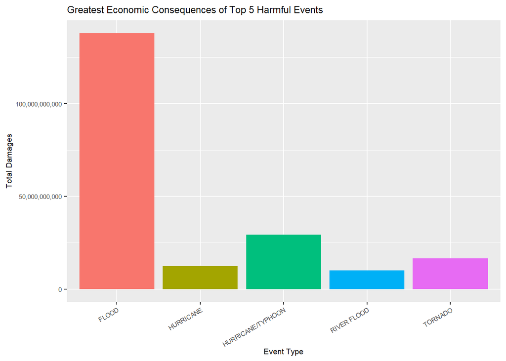

```r
ggplot(data = damage.by.event , aes(y = Damage.Total , x = EVTYPE, fill = EVTYPE))+
    geom_bar(stat = "identity")+
    guides(fill = FALSE)+
    ggtitle("Greatest Economic Consequences of Top 5 Harmful Events")+
    xlab("Event Type")+
    ylab("Total Damages")+
    theme(text = element_text(size=8),axis.text.x=element_text(angle = 30, hjust = 1))+
    scale_y_continuous(labels = comma)
```

*From the above bar graph we can infer that Flood has caused the most economic consequences.*

# Summary

**Hence from the above analysis on the given data, we can conclude that Flood has caused more damage in terms of property and crop damage all together. And from the initial analysis we can infer that tornado has caused more damage in terms of public health and fatalities.**